### Of the features you investigated, were there any unusual distributions?

Having visualized acitric acid and volatile acidity data, I observed some unusual distributions but not bizzare, so I guess this fact may have some correlation with the quality of red wine. Since the data is clean, I did not perform any cleaning process or modification of the data.

Creating boxplots to depict each charcteristics of the dataset.

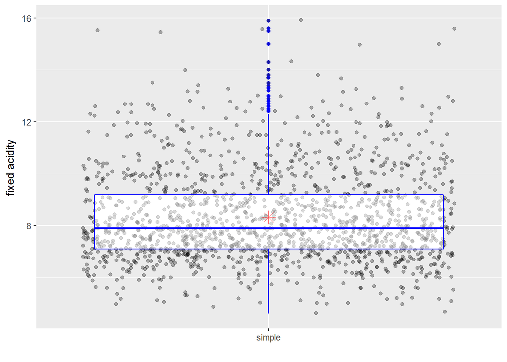

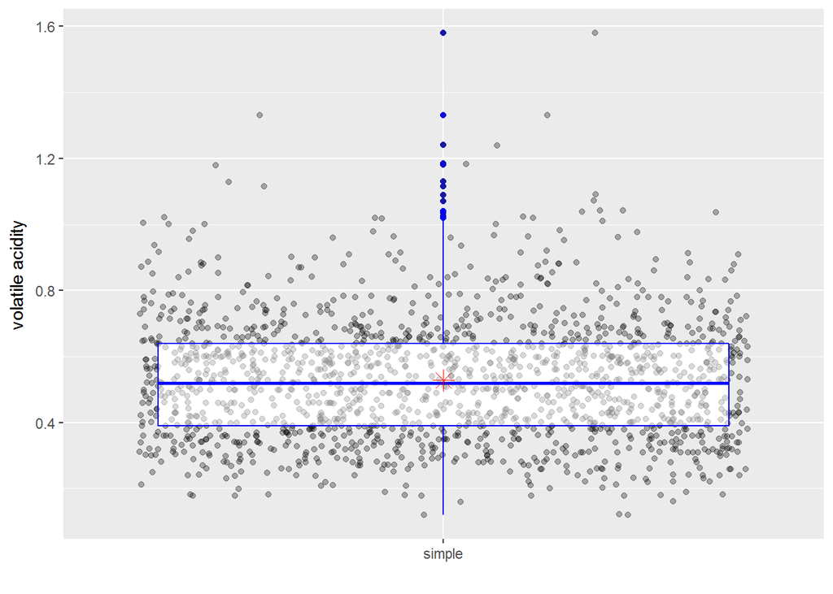

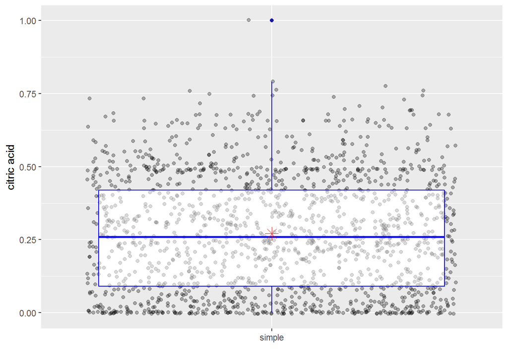

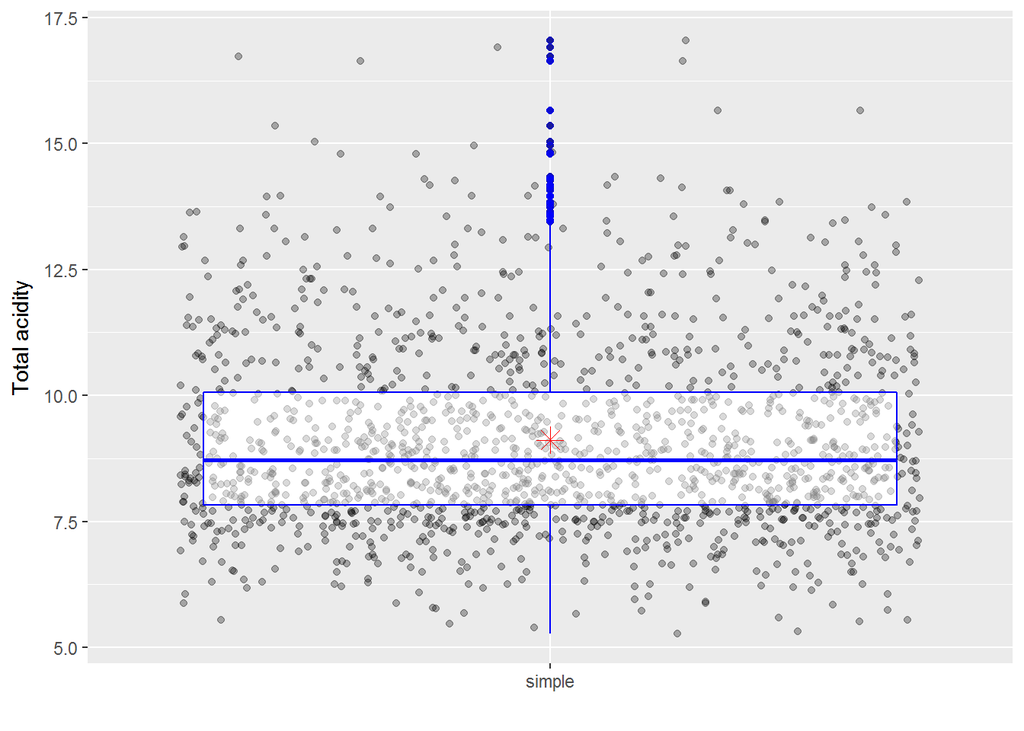

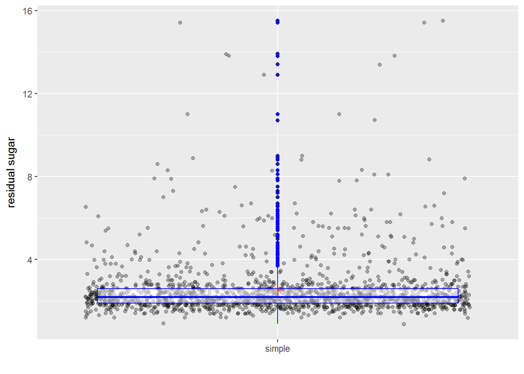

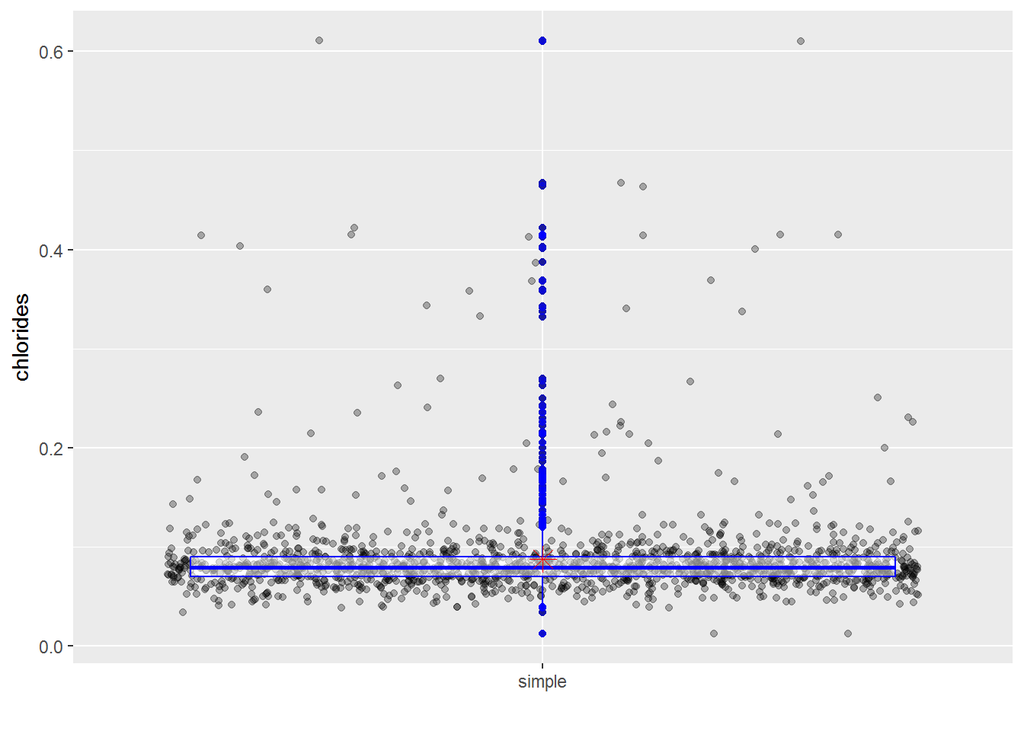

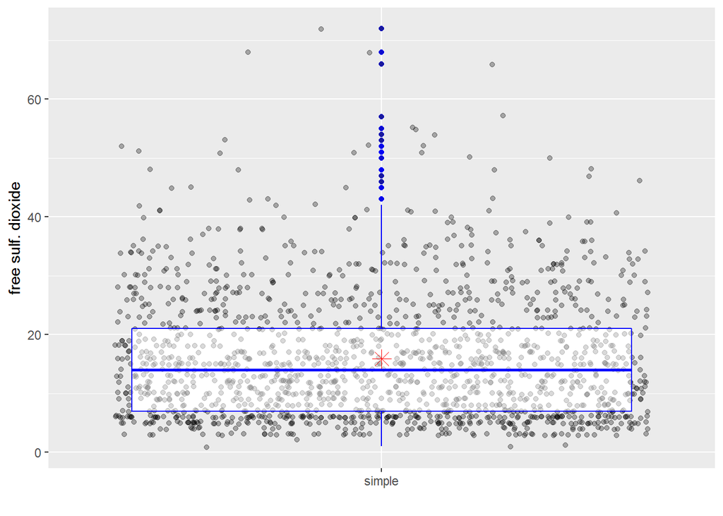

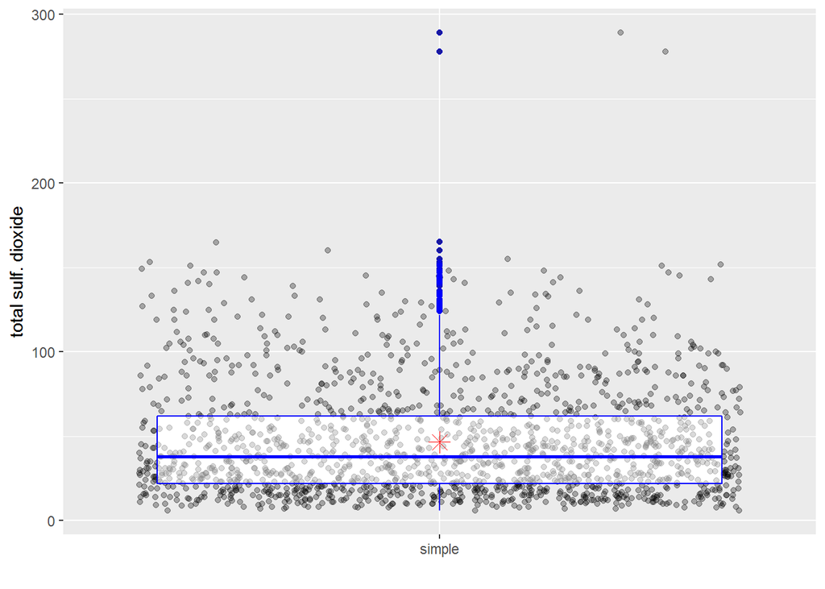

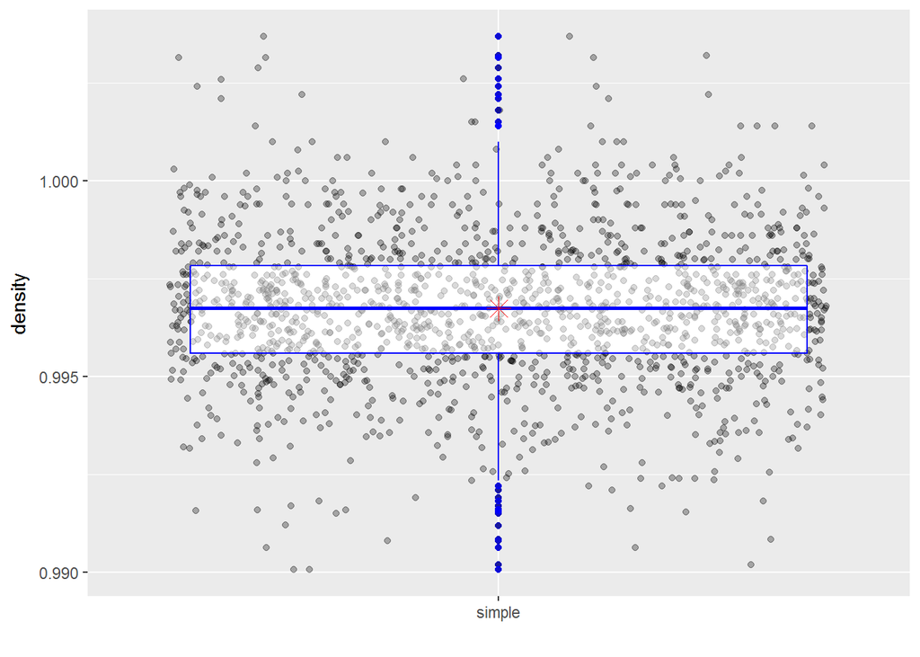

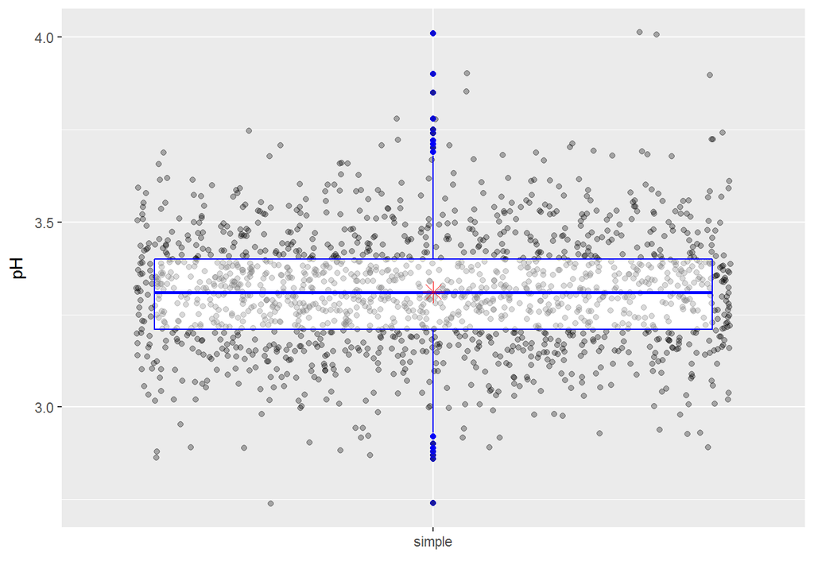

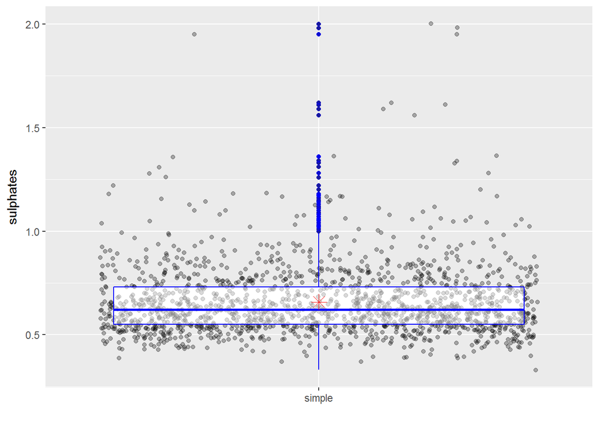

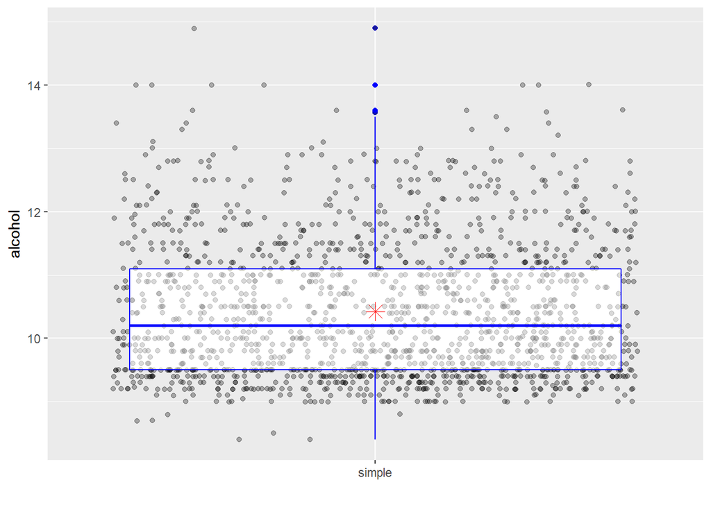

We create box plots for each of the 12 variables which lets us see the distribution of the dataset across the range and the outliers. We mark the mean and use jitter in our plot for better understanding.  
Plots are : 1. Box plot for Fixed acidity - Median is 8, Outliers upto 16  
2. Box plot for Volatile acidity - Median > 0.5, Outliers upto 1.6  
3. Box plot for Citric acidity - Median 0.26 , Outliers upto 1  
4. Box plot for Total acidity - Median is 8.75  
5. Box plot for Residual Sugar - Outliers upto 16  
6. Box plot for Chlorides  
7. Box plot for Free sulphurdioxide  
8. Box plot for total sulphurdioxide  
9. Box plot for Density  
10. Box plot for pH - Most data lies between 3 and 3.5  
11. Box plot for Sulphates  
12. Box plot for Alcohol

Bivariate boxplots, with X as rating or quality, will be more interesting in showing trends with wine quality.

Let us see the difference in our dataset depending on the wine quality.

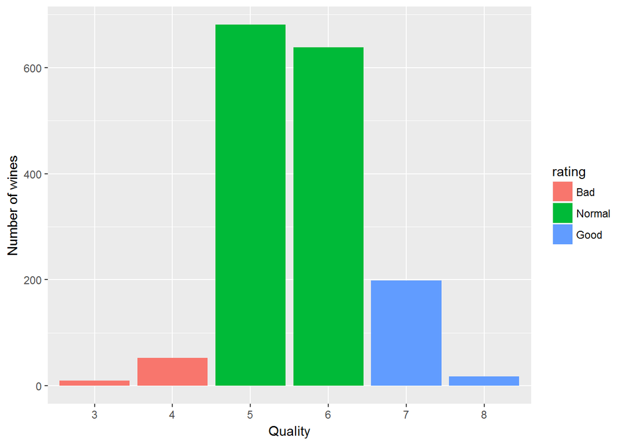

As we can see, we have data mostly belong to normal/average wine.

# Bivariate Plots Section

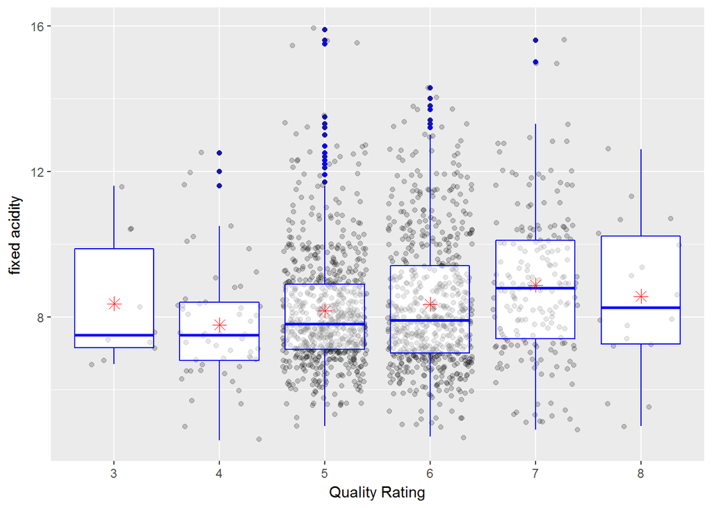

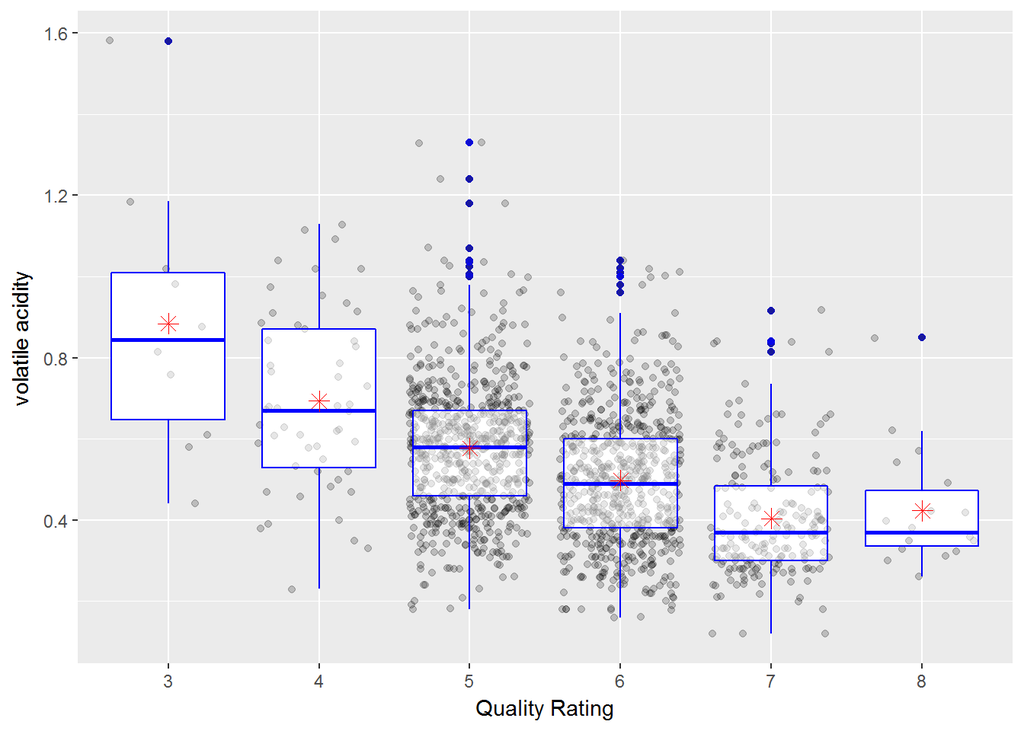

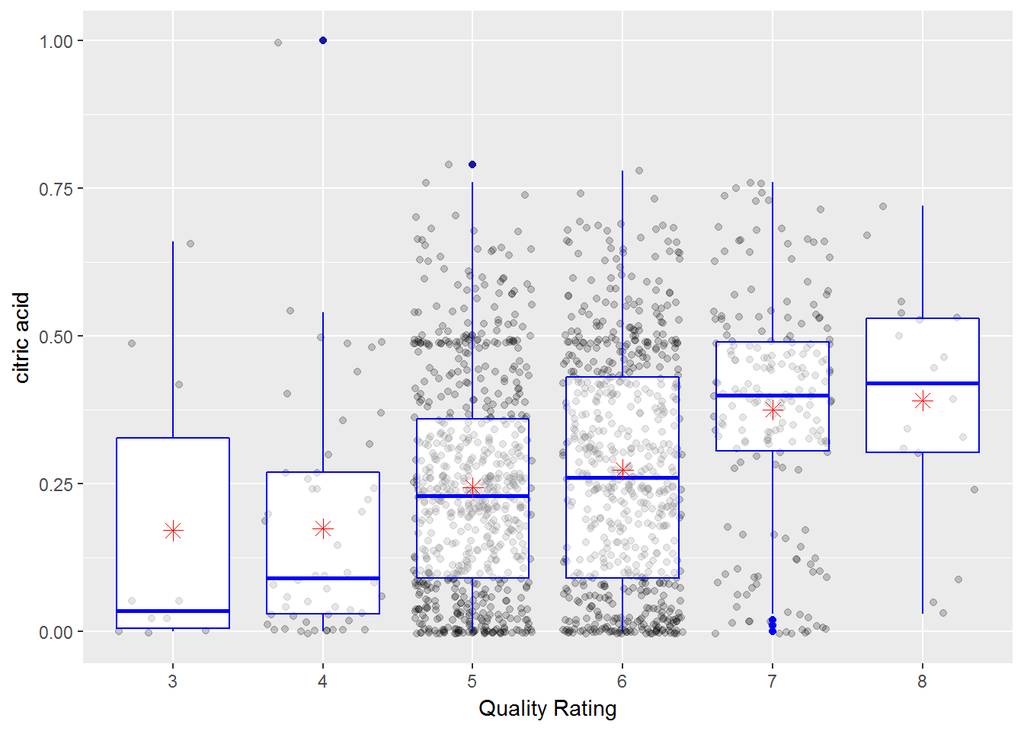

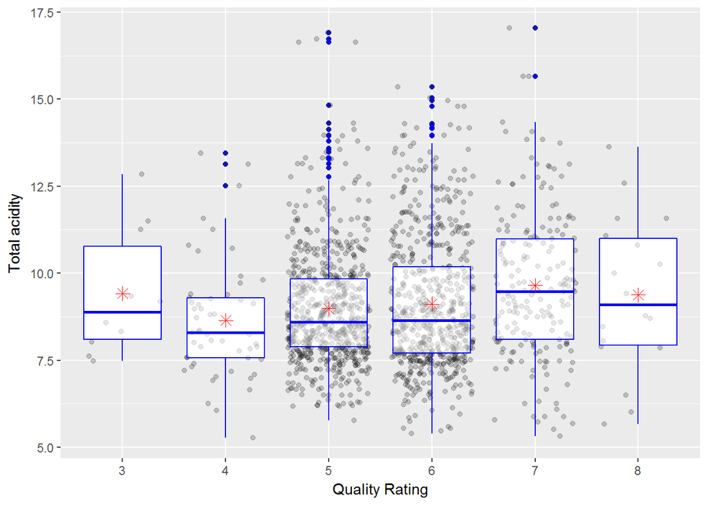

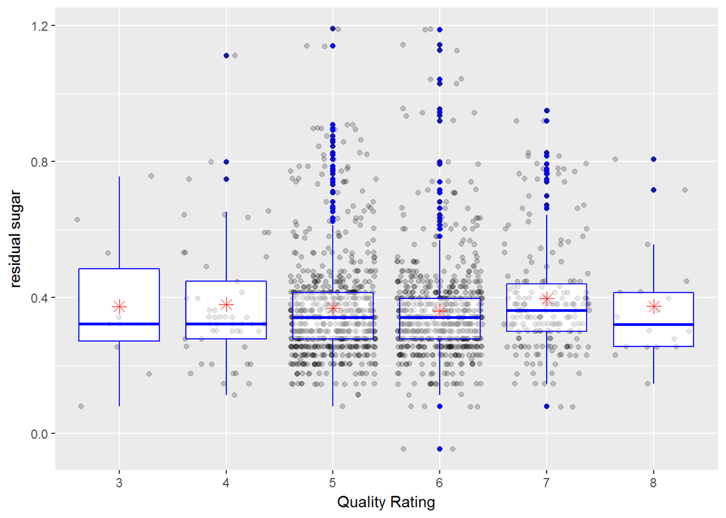

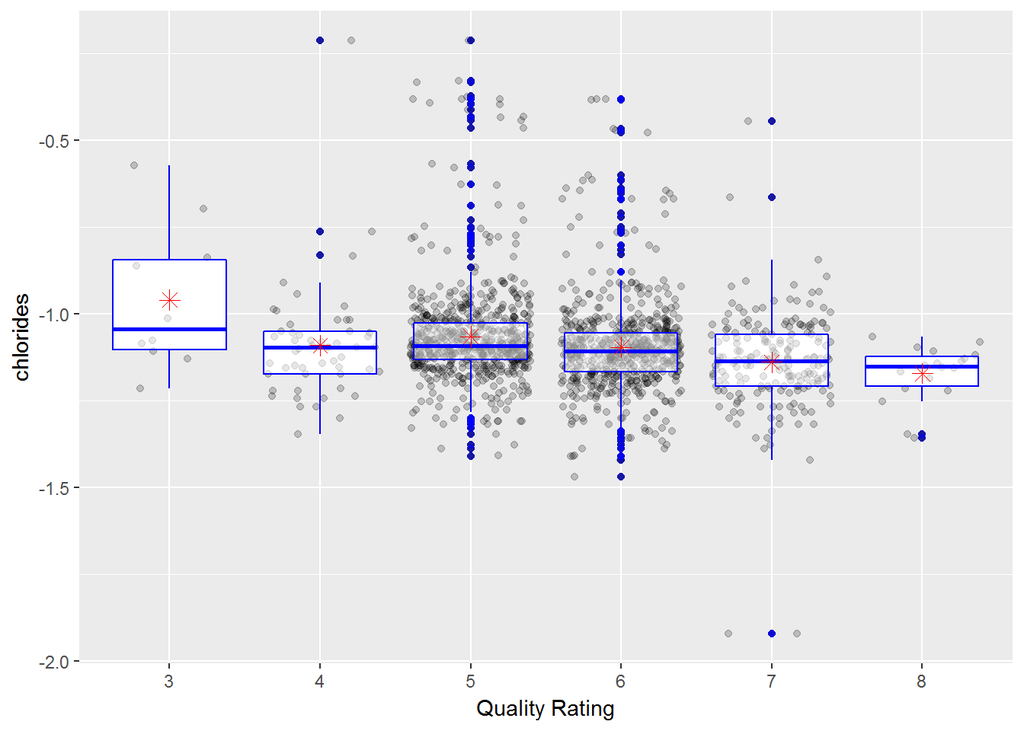

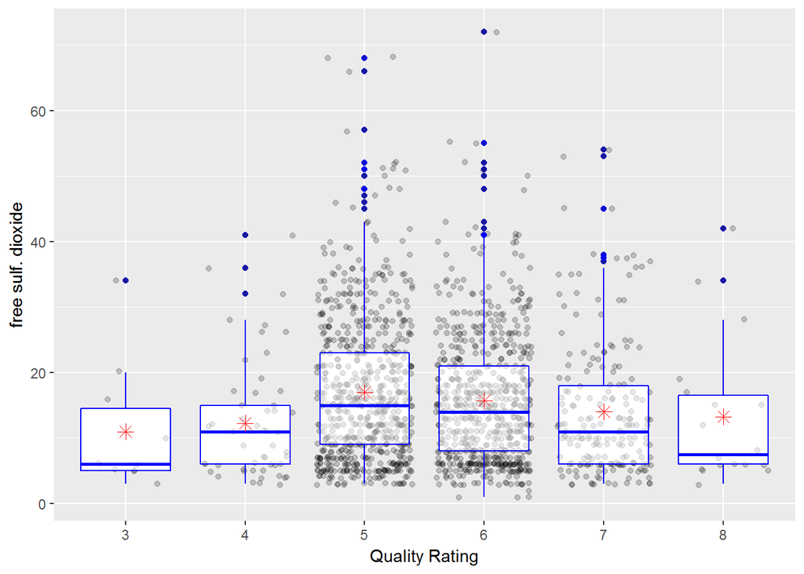

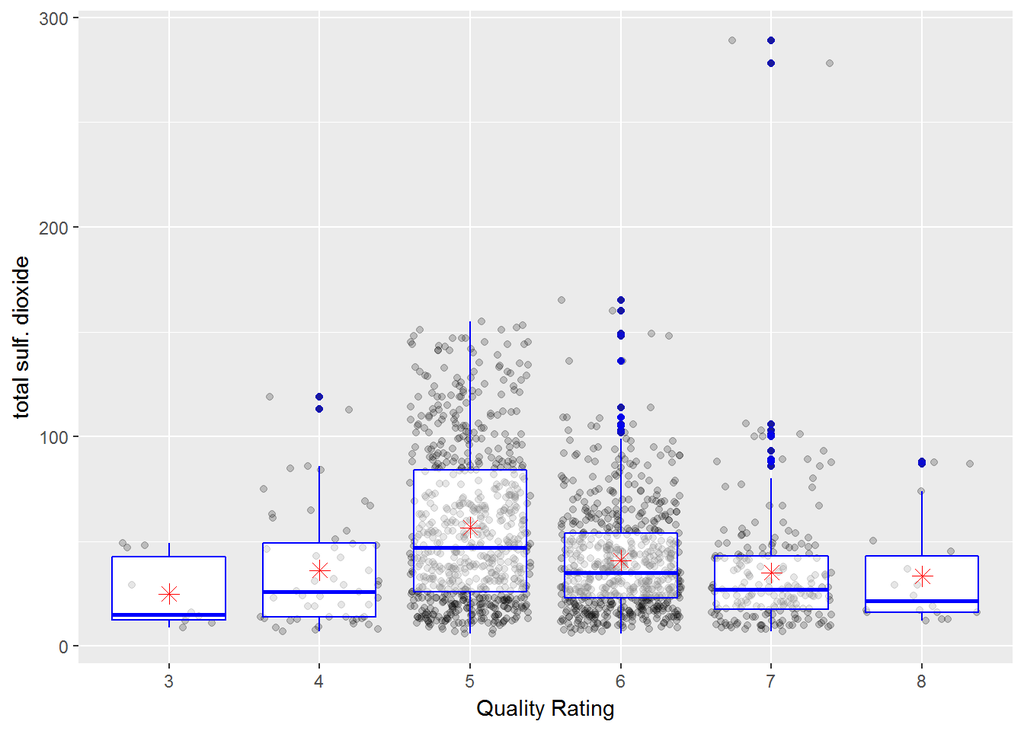

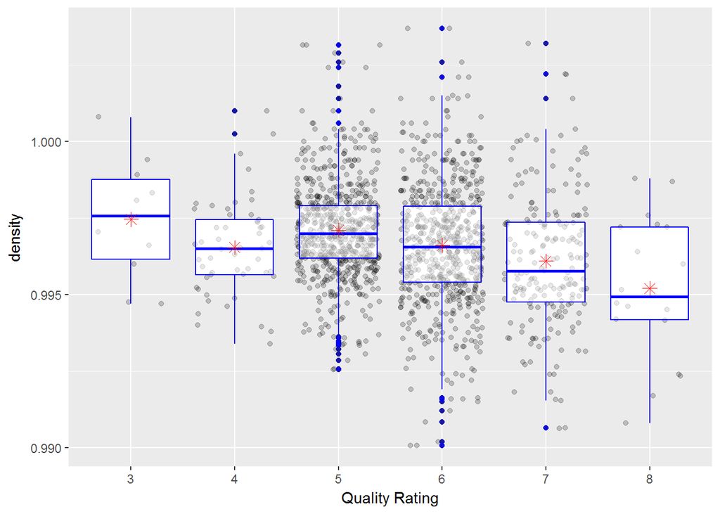

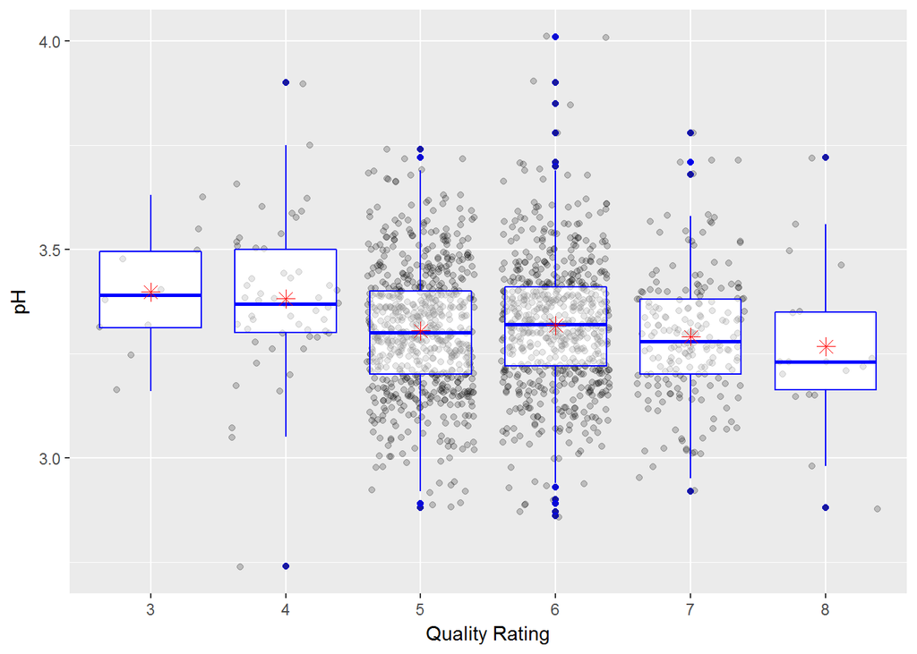

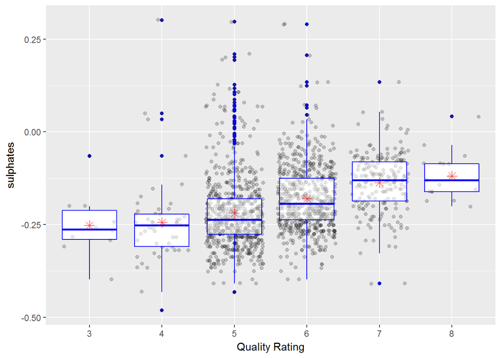

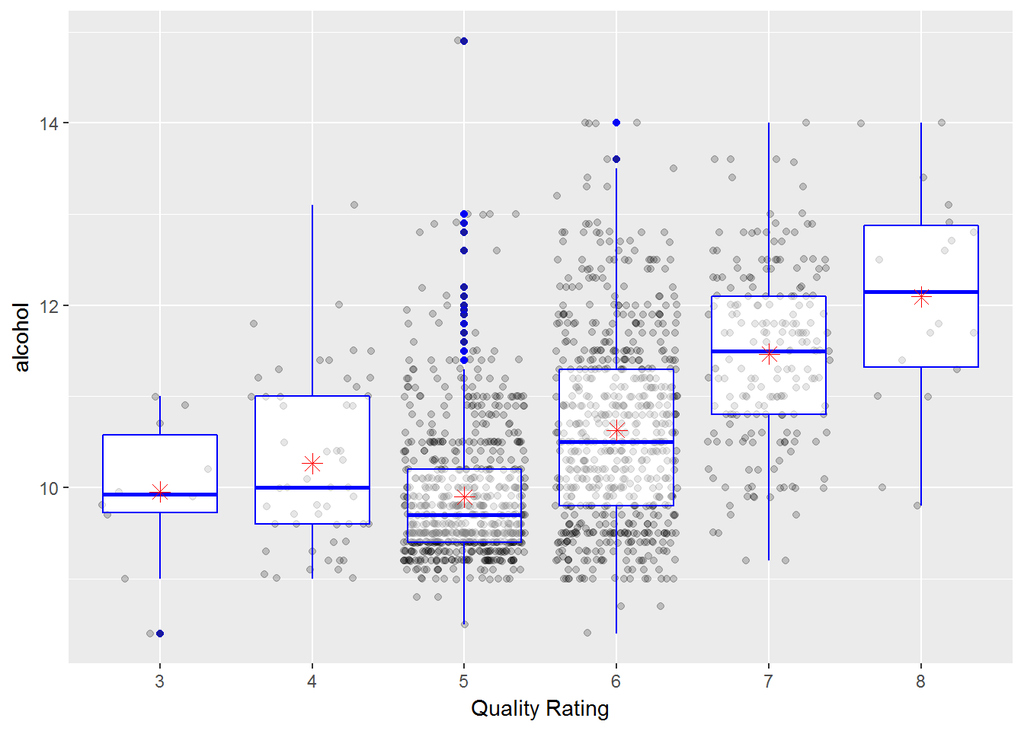

In the above plots, we build bivariate boxplots for each of the 12 variables with respect to the quality variable. We also mark the mean and the jitter for better understanding. These plots are important as it helps us understand how each individual parameter might be affecting the quality of  
the wine. We learn that :

1. Volatile acidity goes down as quality increases.
2. Citric acid content goes up as quality increases.
3. Residual sugar does not have a direct relation with quality.
4. Mean Density is decreasing as we go up in quality.
5. Alcohol level generally goes up as quality increases.